# Sales strategies - Carrefour

Andrew Wairegi

3/2/2022

## Defining the Question

### Specifying the question

To determine the most relevant sales strategies for the marketing team at Carrefour.

### Defining metric for succcess

To be able to create recommendations for the sales team, at Carrefour

### Understanding the context

Carrefour is a leading supermarket brand in Kenya. That has made it’s presence known in Kenya for the last 5 years. It has been in several supermarket stores, including TRM & Garden city. They would like to develop more sales strategies to increase their overall sales.

### Experimental design

1. Loading the data
2. Data cleaning
3. Dimensionality reduction
4. Feature selection
5. Association rules
6. Anomaly detection
7. Recommendation

### Data relevance

The data is relevant because it has been sourced for a Carrefour supermarket. Which means that the data is relevant, and authentic. This means it can be used in our analysis, to create a recommendation for the Carrefour supermarket chain.

## Loading the dataset

```r
# Loading the libraries
library(data.table) # High-performance dataframe package
library(tidyverse) # A Data exploration & visualization Package
library(corrr) # A Correlation package
library(dplyr) # A Data Manipulation package
library(arules)# A Association package
library(anomalize)# A Anomaly package
# Loading the datasets
# Dataset 1
df = fread("Supermarket_dataset1.csv")
head(df)
```

```
##     Invoice ID Branch Customer type Gender           Product line Unit price
## 1: 750-67-8428      A        Member Female      Health and beauty      74.69
## 2: 226-31-3081      C        Normal Female Electronic accessories      15.28
## 3: 631-41-3108      A        Normal   Male     Home and lifestyle      46.33
## 4: 123-19-1176      A        Member   Male      Health and beauty      58.22
## 5: 373-73-7910      A        Normal   Male      Sports and travel      86.31
## 6: 699-14-3026      C        Normal   Male Electronic accessories      85.39
##    Quantity     Tax      Date  Time     Payment   cogs gross margin percentage
## 1:        7 26.1415  1/5/2019 13:08     Ewallet 522.83                4.761905
## 2:        5  3.8200  3/8/2019 10:29        Cash  76.40                4.761905
## 3:        7 16.2155  3/3/2019 13:23 Credit card 324.31                4.761905
## 4:        8 23.2880 1/27/2019 20:33     Ewallet 465.76                4.761905
## 5:        7 30.2085  2/8/2019 10:37     Ewallet 604.17                4.761905
## 6:        7 29.8865 3/25/2019 18:30     Ewallet 597.73                4.761905
##    gross income Rating    Total
## 1:      26.1415    9.1 548.9715
## 2:       3.8200    9.6  80.2200
## 3:      16.2155    7.4 340.5255
## 4:      23.2880    8.4 489.0480
## 5:      30.2085    5.3 634.3785
## 6:      29.8865    4.1 627.6165
```

```r
# Dataset 2
df2 = read.transactions("Supermarket_dataset2.csv")
head(df2)
```

```
## transactions in sparse format with
##  6 transactions (rows) and
##  5729 items (columns)
```

```r
# Dataset 3
df3 = fread("Supermarket_dataset3.csv")
head(df3)
```

```
##         Date    Sales
## 1:  1/5/2019 548.9715
## 2:  3/8/2019  80.2200
## 3:  3/3/2019 340.5255
## 4: 1/27/2019 489.0480
## 5:  2/8/2019 634.3785
## 6: 3/25/2019 627.6165
```

## Data cleaning

```r
# Checking for null values
# Dataframe 1
colSums(is.na(df))
```

```
##              Invoice ID                  Branch           Customer type
##                       0                       0                       0
##                  Gender            Product line              Unit price
##                       0                       0                       0
##                Quantity                     Tax                    Date
##                       0                       0                       0
##                    Time                 Payment                    cogs
##                       0                       0                       0
## gross margin percentage            gross income                  Rating
##                       0                       0                       0
##                   Total
##                       0
```

```r
# Note: Duplicated and null values
# are automatically removed from dataframe 2, during reading.
```

```r
# Dataframe 3
colSums(is.na(df3))
```

```
##  Date Sales
##     0     0
```

```r
# Checking for duplicates
# Dataframe 1
sum(duplicated(df))
```

```
## [1] 0
```

```r
# Note: duplicates have already been removed for
# dataframe 2
```

```r
# Dataframe 3
sum(duplicated(df3))
```

```
## [1] 0
```

```r
# Checking for outliers

# Dataframe 1
cat("Unit price:", max(df$`Unit price`), "\n")
```

```
## Unit price: 99.96
```

```r
cat("Tax: ", max(df$Tax), "\n")
```

```
## Tax:  49.65
```

```r
cat("Gross margin percentage: ",  max(df$`gross margin percentage`), "\n")
```

```
## Gross margin percentage:  4.761905
```

```r
cat("Gross income: ", max(df$`gross income`), "\n")
```

```
## Gross income:  49.65
```

```r
cat("Rating: ", max(df$Rating), "\n")
```

```
## Rating:  10
```

```r
cat("Total: ", max(df$Total))
```

```
## Total:  1042.65
```

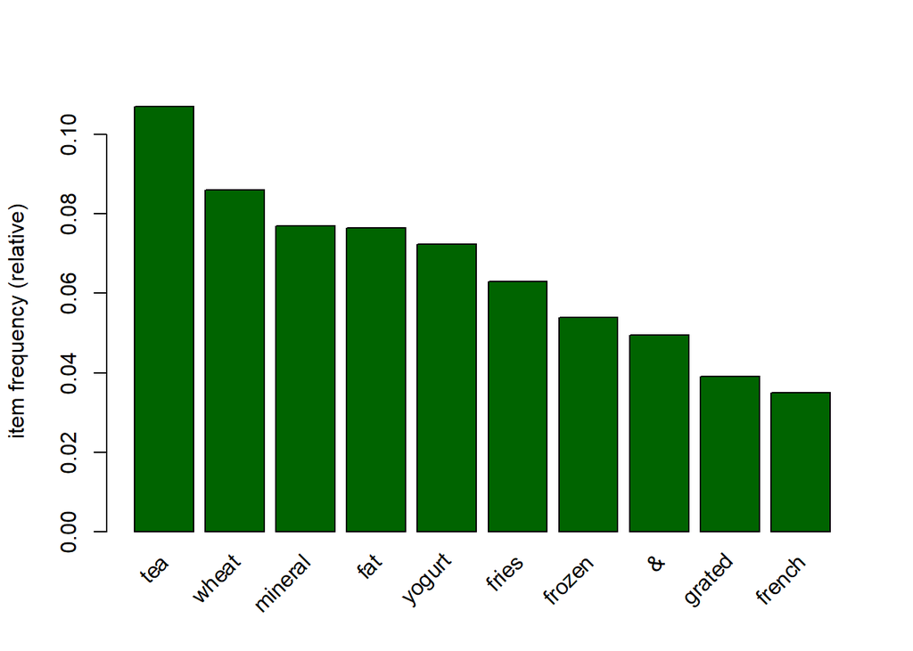

```r
itemFrequencyPlot(df2, topN = 10,col="darkgreen")
```

There are no clear outliers. So the data is clean

```r
max(df3$Sales)
```

```
## [1] 1042.65
```

A max sale of 1042 is ok. Because their are other sales, over $500.

## Dimensionality reduction

Note: Dimensionality reduction, is being done with dataset 1.

```r
head(df)
```

```
##     Invoice ID Branch Customer type Gender           Product line Unit price
## 1: 750-67-8428      A        Member Female      Health and beauty      74.69
## 2: 226-31-3081      C        Normal Female Electronic accessories      15.28
## 3: 631-41-3108      A        Normal   Male     Home and lifestyle      46.33
## 4: 123-19-1176      A        Member   Male      Health and beauty      58.22
## 5: 373-73-7910      A        Normal   Male      Sports and travel      86.31
## 6: 699-14-3026      C        Normal   Male Electronic accessories      85.39
##    Quantity     Tax      Date  Time     Payment   cogs gross margin percentage
## 1:        7 26.1415  1/5/2019 13:08     Ewallet 522.83                4.761905
## 2:        5  3.8200  3/8/2019 10:29        Cash  76.40                4.761905
## 3:        7 16.2155  3/3/2019 13:23 Credit card 324.31                4.761905
## 4:        8 23.2880 1/27/2019 20:33     Ewallet 465.76                4.761905
## 5:        7 30.2085  2/8/2019 10:37     Ewallet 604.17                4.761905
## 6:        7 29.8865 3/25/2019 18:30     Ewallet 597.73                4.761905
##    gross income Rating    Total
## 1:      26.1415    9.1 548.9715
## 2:       3.8200    9.6  80.2200
## 3:      16.2155    7.4 340.5255
## 4:      23.2880    8.4 489.0480
## 5:      30.2085    5.3 634.3785
## 6:      29.8865    4.1 627.6165
```

```r
df_analysis = select(df, `Unit price`, Quantity, Tax)
PCA <- prcomp(df_analysis, center = TRUE, scale. = TRUE) # Note some columns had zero variance, so they could not be scaled
```

```r
summary(PCA)
```

```
## Importance of components:
##                           PC1    PC2     PC3
## Standard deviation     1.3978 0.9946 0.23842
## Proportion of Variance 0.6513 0.3298 0.01895
## Cumulative Proportion  0.6513 0.9810 1.00000
```

Note: The first principal component explains for 65.13% of the variance. While the second principal component, explains for 32.98% of the variance. This means we can get most of our variables that explain variance from the first & second principal component.

```r
PCA
```

```
## Standard deviations (1, .., p=3):
## [1] 1.3978105 0.9946275 0.2384159
##
## Rotation (n x k) = (3 x 3):
##                   PC1         PC2        PC3
## Unit price -0.4745795  0.74382522 -0.4706361
## Quantity   -0.5268771 -0.66837308 -0.5250504
## Tax        -0.7051062 -0.00121074  0.7091006
```

Based on the PCA. We can see that tax explains the most variance in the dataset. Then quantity. Then unit price. However in the second principal component, price is the most important indicator.

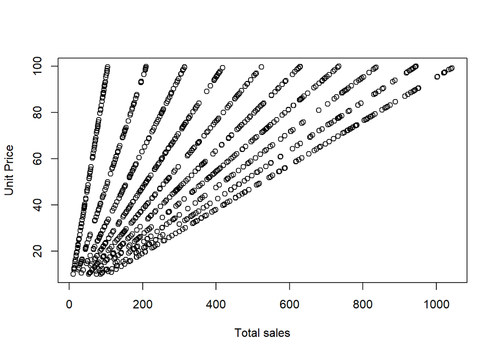

```r
plot(df$Total, df$`Unit price`, xlab = "Total sales", ylab = "Unit Price")
```

It seems that for different product categories. As the unit price increases, the sales increase. This might be that more expensive products in one line, sell more. When compared to cheaper products in the same line. For example, a cheap hair brush vs a expensive hair brush.

## Feature selection

If we were to create a model we would need to do feature selection. So to practise that now would be a good idea in case we need to create a model in the future.

```r
correlation = correlate(select_if(df, is.numeric))
```

```
##
## Correlation method: 'pearson'
## Missing treated using: 'pairwise.complete.obs'
```

```r
correlation
```

```
## # A tibble: 8 x 9
##   term    `Unit price` Quantity     Tax    cogs `gross margin pe~ `gross income`
##   <chr>          <dbl>    <dbl>   <dbl>   <dbl>             <dbl>          <dbl>
## 1 Unit p~     NA         0.0108  0.634   0.634                 NA         0.634
## 2 Quanti~      0.0108   NA       0.706   0.706                 NA         0.706
## 3 Tax          0.634     0.706  NA       1                     NA         1
## 4 cogs         0.634     0.706   1      NA                     NA         1
## 5 gross ~     NA        NA      NA      NA                     NA        NA
## 6 gross ~      0.634     0.706   1       1                     NA        NA
## 7 Rating      -0.00878  -0.0158 -0.0364 -0.0364                NA        -0.0364
## 8 Total        0.634     0.706   1       1                     NA         1
## # ... with 2 more variables: Rating <dbl>, Total <dbl>
```

```r
correlation[, c("term", "Total")]
```

```
## # A tibble: 8 x 2
##   term                      Total
##   <chr>                     <dbl>
## 1 Unit price               0.634
## 2 Quantity                 0.706
## 3 Tax                      1
## 4 cogs                     1
## 5 gross margin percentage NA
## 6 gross income             1
## 7 Rating                  -0.0364
## 8 Total                   NA
```

It seems that tax & cost of goods are perfect correlators of the total sales. However, this is because they are directly part of the total. As they are constants, that will be used to create the total.

However unit price is a good indicator of how much an item will sell. As it may relate to how expensive the item is in the supermarket. Also quantity is another good indicator, as it relates to how popular the item is already in the supermarket. So it will determine how many times the item will be bought in the future.

## Association rules

Note: we will use dataset two to find out the most popular products in the store. This will allow us to find out which other products should be stocked, other than just looking at price.

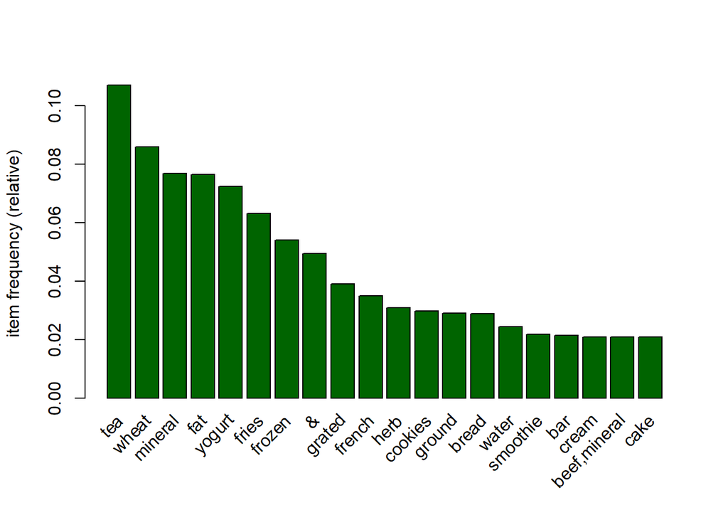

```r
# Top 20 items in store
itemFrequencyPlot(df2, topN = 20,col="darkgreen")
```

```r
associations <- apriori (df2, parameter = list(supp = 0.001, conf = 0.8))
```

```
## Apriori
##
## Parameter specification:
##  confidence minval smax arem  aval originalSupport maxtime support minlen
##         0.8    0.1    1 none FALSE            TRUE       5   0.001      1
##  maxlen target  ext
##      10  rules TRUE
##
## Algorithmic control:
##  filter tree heap memopt load sort verbose
##     0.1 TRUE TRUE  FALSE TRUE    2    TRUE
##
## Absolute minimum support count: 7
##
## set item appearances ...[0 item(s)] done [0.00s].
## set transactions ...[5729 item(s), 7501 transaction(s)] done [0.01s].
## sorting and recoding items ... [354 item(s)] done [0.00s].
## creating transaction tree ... done [0.00s].
## checking subsets of size 1 2 3 4 done [0.00s].
## writing ... [271 rule(s)] done [0.00s].
## creating S4 object  ... done [0.00s].
```

```r
inspect(associations[1:10])
```

```
##      lhs                                rhs      support     confidence
## [1]  {cookies,low}                   => {yogurt} 0.001066524 1.0
## [2]  {cookies,low}                   => {fat}    0.001066524 1.0
## [3]  {extra}                         => {dark}   0.001066524 1.0
## [4]  {burgers,whole}                 => {wheat}  0.001199840 1.0
## [5]  {fries,escalope,pasta,mushroom} => {cream}  0.001066524 1.0
## [6]  {fries,cookies,green}           => {tea}    0.001333156 1.0
## [7]  {shrimp,whole}                  => {wheat}  0.001066524 1.0
## [8]  {rice,cake}                     => {wheat}  0.001333156 1.0
## [9]  {tomatoes,whole}                => {wheat}  0.001066524 0.8
## [10] {rice,chocolate}                => {wheat}  0.001199840 0.9
##      coverage    lift      count
## [1]  0.001066524 13.813996  8
## [2]  0.001066524 13.067944  8
## [3]  0.001066524 83.344444  8
## [4]  0.001199840 11.629457  9
## [5]  0.001066524 47.777070  8
## [6]  0.001333156  9.341220 10
## [7]  0.001066524 11.629457  8
## [8]  0.001333156 11.629457 10
## [9]  0.001333156  9.303566  8
## [10] 0.001333156 10.466512  9
```

```r
length(associations)
```

```
## [1] 271
```

## Anomaly Detection

```r
anomally_df = anomalize(data = as_tibble(df3), target = "Sales")
anomalies = anomally_df[anomally_df$anomaly == "Yes",]
anomalies[, c("Date", "Sales", "anomaly")]
```

```
## # A tibble: 0 x 3
## # ... with 3 variables: Date <chr>, Sales <dbl>, anomaly <chr>
```

Note: There are no anomalies. This means that this data is true. That every record is accurate. This means I can trust the observations. That the analysis is correct.

## Recommendation

The best thing that the supermarket can do is stock up on the items that are most sold. This will allow them to be always prepared for a rush for these items. As well as this they can put items that are most commonly bought together, in the same place. So that shoppers are more easily able to buy them. This may also increase the number of items that are bought, in pairs. As well as this, they can also think of introducing more variety in to these product lines that are frequently bought. For example, a burger bar, or different varieties of flavoured water. To increase sales. This will increase sales, and will increase customer reliability in the store. These are the tips that I can give to Carrefour supermarket brand.